# Avocado Economics: Why Your Toast Costs More

A Data Story on Organic vs Conventional Avocado Prices (2015–2020)

Kati Luechtefeld

November 14, 2025

Avocado toast has quickly become a brunch staple, but people often joke about how expensive it is. It turns out there are economic trends to explain this. How have avocado prices actually changed over recent years, and how do organic and non-organic avocados compare? Using data from 2015 to 2020, I will explore the difference between organic and non-organic avocado prices over time and discuss the impact this has on our favorite brunch food.

### Data and Graphs

```r
avocado_data <- read.csv("avocado-updated-2020.csv")
```

```r
#Calculate the average mean and median price of avocados sorted by type.
average_prices <- avocado_data %>%
  group_by(type) %>%
  summarise(
    mean_price = mean(average_price, na.rm = TRUE),
    median_price = median(average_price, na.rm = TRUE),
    n = n()
  )
average_prices
```

```
## # A tibble: 2 × 4
##   type         mean_price median_price     n
##   <chr>             <dbl>        <dbl> <int>
## 1 conventional       1.14         1.12 16524
## 2 organic            1.62         1.58 16521
```

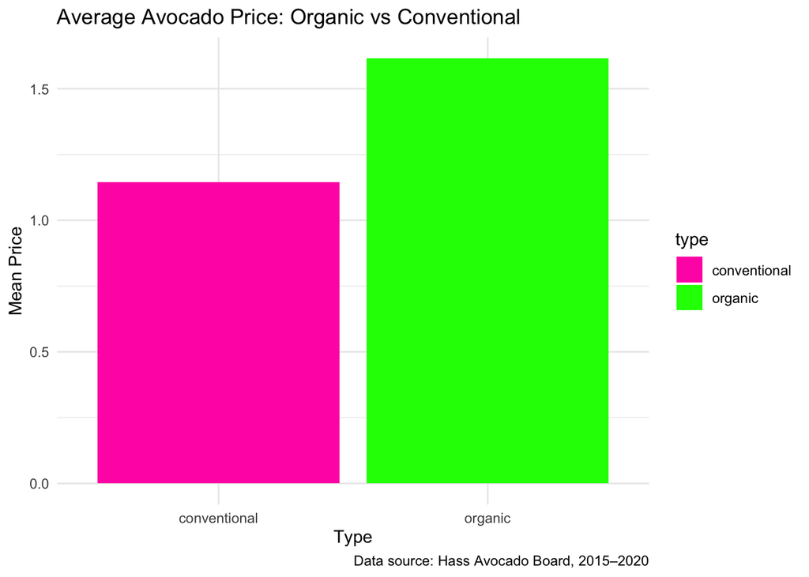

```r
ggplot(average_prices, aes(x = type, y = mean_price, fill = type)) +
  geom_col() +
  scale_fill_manual(values = c("conventional" = "maroon1",
                                "organic" = "green")) +
  labs(title = "Average Avocado Price: Organic vs Conventional",
  x = "Type",
  y = "Mean Price",
  caption = "Data source: Hass Avocado Board, 2015–2020"
  ) +
  theme_minimal()
```

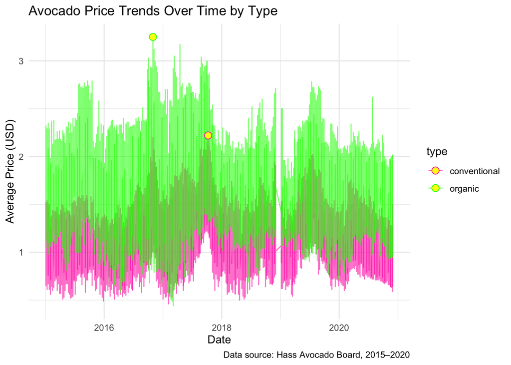

```r
avocado_data$date <- as.Date(avocado_data$date)

#Find the peak dates where avocado prices were the highest per type.
peak_dates <- avocado_data %>%
  group_by(type) %>%
  filter(average_price == max(average_price, na.rm = TRUE)) %>%
  select(date, type, average_price)

ggplot(avocado_data, aes(x = date, y = average_price, color = type)) +
  geom_line(alpha = 0.6) +
  geom_point(data = peak_dates, aes(x = date, y = average_price),
             size = 3, shape = 21, fill = "yellow") +
  scale_color_manual(values = c("conventional" = "maroon1",
                                "organic" = "green")) +
  labs(
    title = "Avocado Price Trends Over Time by Type",
    x = "Date",
    y = "Average Price (USD)",
    caption = "Data source: Hass Avocado Board, 2015–2020"
  ) +
  theme_minimal()
```

```r
#Find the maximum price of avocados per year sorted by type.
avocado_data %>%
  group_by(year, type) %>%
  summarise(max_price = max(average_price, na.rm = TRUE), .groups = "drop") %>%
  arrange(year)
```

```
## # A tibble: 12 × 3
##     year type         max_price
##    <int> <chr>            <dbl>
##  1  2015 conventional      1.59
##  2  2015 organic           2.79
##  3  2016 conventional      2.2
##  4  2016 organic           3.25
##  5  2017 conventional      2.22
##  6  2017 organic           3.17
##  7  2018 conventional      1.95
##  8  2018 organic           2.71
##  9  2019 conventional      2.02
## 10  2019 organic           2.78
## 11  2020 conventional      1.76
## 12  2020 organic           2.62
```

### Analysis

The bar plot compares the mean price of avocados and the type (organic vs. conventional). Organic avocados are clearly more expensive, with an average price of about $1.62 USD, while conventional avocados have an average price of about $1.15 USD.

The line plot above compares avocado prices from 2015 to 2020. From the graph, we see that conventional avocados have remained cheaper than organic avocados. Organic avocado prices peaked towards the end of 2016 and again at the end of 2017. The maximum price of organic avocados in 2016 was $3.25, and $3.17 in 2017. Prices of conventional avocados also peaked at the end of 2016 and 2017, with a maximum price of $2.20 in 2016 and $2.22 in 2017.

What caused the spike in prices in 2016 and 2017? According to BBC News (2017) [link](https://www.bbc.com/news/business-39768480), there was a serious increase in the demand for avocados due to their rise in popularity as a health food. At the same time, avocado producers in Mexico, Peru, and California experienced lower production. There were strikes in Mexico and a drought in California. As seen in the graph, when demand increased dramatically in 2016 and 2017, supply could not keep up, and prices rose sharply.

Although the graphs focus on the price of organic vs non-organic avocados, it’s interesting to note how avocado toast became a cultural phenomenon. According to Uyehara (2018) [link](https://tastecooking.com/really-invented-avocado-toast/), the modern dish served at many cafes gained popularity in the ’90s in Australia, and then took off in Southern California in the 2010s via Instagram. This trend increased demand, contributing to the price fluctuations we observe in the data.

Overall, organic avocados cost more than conventional avocados. Prices spiked during a high-demand time from 2016 to 2017. Since the data has not been updated since 2020, it would be interesting to explore how prices have fluctuated since then and quantify the effect of social media food trends on prices. Avocados offer an example of how social media trends have a ripple effect on demand, supply, and prices.

### References

- BBC News. (2017, May 1). *Avocado prices at record high due to reduced harvests* [link](https://www.bbc.com/news/business-39768480)
- Hass Avocado Board. (2020). *Avocado Prices 2020 [Dataset].* Compiled and updated by Timofei Kornev on Kaggle. [link](https://www.kaggle.com/datasets/timmate/avocado-prices-2020)
- Uyehara, S. (2018, Jan. 15). *Who Really Invented Avocado Toast?* [link](https://tastecooking.com/really-invented-avocado-toast/)